# Analyzing Edits on HRC's page

Author: Ngina Kariuki, Ana Fernandez, Angelina Li Oct 29, 2017

**Research questions:** Did big news stories associated with Hillary Clinton cause more edit wars to occur on her page, as opposed to just adding new information while not necessarily causing edit wars? We will analyze this question by looking at the controversiality of HRC's page just before and right after controversial events occured.

**Hypothesis:** Our hypothesis is that big news stories about Hillary Clinton caused more edit wars to occur on her page.

**Controversiality:** We will use the number of reversions on a page as a proportion of the total number of edits on that page as a measure of how controversial a Wikipedia page is on any given day.

**Table of Contents**

1. Connecting to HRC's page and getting revisions
2. Distribution of revisions in 2016
3. Distribution of edits in October and November of 2016
4. Getting diffsize edits for each day in October and November 2016
5. Mapping diffsize to days
6. Defining controversiality metric
7. Parse HTML page

## 1. Connecting to HRC's page and getting revisions

```python
from mwclient import Site
site = Site('en.wikipedia.org')
pg = site.pages['Hillary Clinton']
```

```python
# revisions = [rev for rev in pg.revisions()]
# len(revisions)
```

```python
# revisions[:5]
```

In order to not repeat this step in the future, we are adding all the revisions to a JSON file.

```python
# import json
# with open('HRC_revisions.json','w') as f:
#     json.dump(revisions, f)
```

```python
import json
with open('HRC_revisions.json','r') as f:
    revisions = json.load(f)
```

```python
print(revisions[0])
type(revisions[0]['timestamp'])
```

```
{'revid': 810992605, 'parentid': 810850742, 'user': 'Beyond My Ken', 'timestamp': [2017, 11, 18, 21, 4, 14, 5, 322, -1], 'comment': 'rem per [[WP:WEIGHT]] and [[WP:NPOV]]'}
```

```
list
```

## 2. Distribution of revisions in 2016

```python
import json
from time import mktime
from datetime import datetime

def createDateTime(rev):
    return datetime.fromtimestamp(mktime(tuple(rev['timestamp'])))

timestamps = [createDateTime(rev) for rev in revisions]
len(timestamps)
```

```
15621
```

```python
from collections import Counter

all_months_count = [ts.month for ts in timestamps if ts.year==2016]
print(len(all_months_count))
```

```
2107
```

```python
months_count = Counter(all_months_count)
```

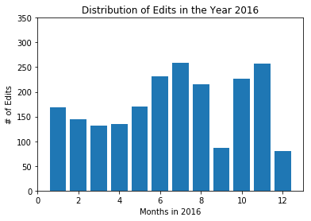

```python
import matplotlib.pyplot as plt
#ensures plots will show up inline in the notebook
%matplotlib inline
plt.bar([x for x in months_count.keys()], [y for y in months_count.values()])
plt.axis([0, 13, 0, 350])
plt.xlabel('Months in 2016')
plt.ylabel('# of Edits')
plt.title('Distribution of Edits in the Year 2016')
plt.show()
```

## 3. Distribution of edits in October and November of 2016

```python
edits_in_oct = [ts.day for ts in timestamps if ts.year==2016 and ts.month==10]
all_edits_in_oct = Counter(edits_in_oct)
```

```python
print('Number of edits in October in 2016: {}'.format(len(all_edits_in_oct)))
```

[output not shown]

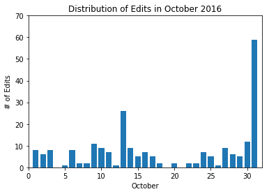

```python
plt.bar([x for x in all_edits_in_oct.keys()], [y for y in all_edits_in_oct.values()])
plt.axis([0, 32, 0, 70])
plt.xlabel('October')
plt.ylabel('# of Edits')
plt.title('Distribution of Edits in October 2016')
plt.show()
```

```python
edits_in_nov = [ts.day for ts in timestamps if ts.year==2016 and ts.month==11]
all_edits_in_nov = Counter(edits_in_nov)
```

```python
print('Number of edits in November in 2016: {}'.format(len(all_edits_in_nov)))
```

[output not shown]

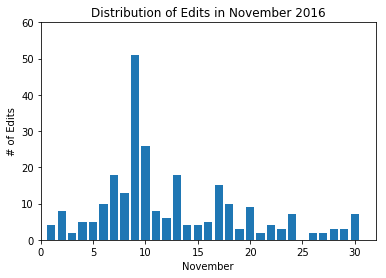

```python
plt.bar([x for x in all_edits_in_nov.keys()], [y for y in all_edits_in_nov.values()])
plt.axis([0, 32, 0, 60])
plt.xlabel('November')
plt.ylabel('# of Edits')
plt.title('Distribution of Edits in November 2016')
plt.show()
```

## 4. Getting diffsize edits for each day in October and November 2016

```python
revisions_in_2016 = [rev for rev in revisions if createDateTime(rev).year == 2016]
```

```python
revisions_in_oct = [rev for rev in revisions_in_2016 if createDateTime(rev).month == 10]
```

```python
revisions_in_nov = [rev for rev in revisions_in_2016 if createDateTime(rev).month == 11]
revisions_in_nov[0]
```

```
{'comment': 'Reverted edits by [[Special:Contributions/JohnTopShelf|JohnTopShelf]] ([[User talk:JohnTopShelf|talk]]) ([[WP:HG|HG]]) (3.1.22)',
 'minor': '',
 'parentid': 752311830,
 'revid': 752311915,
 'timestamp': [2016, 11, 30, 15, 45, 10, 2, 335, -1],
 'user': 'Smd75jr'}
```

```python
import requests
def list_of_diffsize(revisions):
    """Returns list of diffsize and list of datestring for the given revision"""

    urlbase = "https://en.wikipedia.org/w/api.php"
    diffsize_list, datestr_for_month = [], []

    for rev in revisions:
        req = requests.get(url=urlbase, params = { 'action': 'compare',
                                                    'format': 'json',
                                                    'prop': 'size|diffsize|user',
                                                    'fromrev': rev['parentid'],
                                                    'torev': rev['revid']})
        response = json.loads(req.content)
        try:
            diffsize_list.append(response['compare']['diffsize'])
        except KeyError:
            print(rev)
            diffsize_list.append(0)

        datestr_for_month.append(createDateTime(rev))

    return diffsize_list, datestr_for_month
```

```python
diffsize_list_oct, datestr_for_oct = list_of_diffsize(revisions_in_oct)
```

```python
len(diffsize_list_oct), len(datestr_for_oct)
```

```
(227, 227)
```

```python
diffsize_list_nov, datestr_for_nov = list_of_diffsize(revisions_in_nov)
```

```
{'revid': 749037473, 'parentid': 749037394, 'user': 'Arkon', 'timestamp': [2016, 11, 11, 23, 53, 40, 4, 316, -1], 'comment': 'Revert to revision 749031809 dated 2016-11-11 22:57:42 by Zzuuzz using [[:en:Wikipedia:Tools/Navigation_popups|popups]]'}
{'revid': 749037394, 'parentid': 749031809, 'minor': '', 'user': 'Jimbo Wales', 'timestamp': [2016, 11, 11, 23, 53, 0, 4, 316, -1], 'comment': 'Rank'}
{'revid': 749031809, 'parentid': 749031757, 'minor': '', 'user': 'Zzuuzz', 'timestamp': [2016, 11, 11, 22, 57, 42, 4, 316, -1], 'comment': 'Reverted edits by [[Special:Contribs/Ijon|Ijon]] ([[User talk:Ijon|talk]]) to last version by MordeKyle'}
{'revid': 749031757, 'parentid': 749030747, 'minor': '', 'user': 'Ijon', 'timestamp': [2016, 11, 11, 22, 57, 13, 4, 316, -1], 'commenthidden': ''}
```

```python
len(diffsize_list_nov), len(datestr_for_nov)
```

```
(257, 257)
```

## 5. Mapping diffsize to days

```python
import pandas as pd
from pandas import Series, DataFrame
from datetime import datetime
import numpy as np
```

```python
# time series for revisions in oct
ts_in_oct = Series(diffsize_list_oct, index=datestr_for_oct)
ts_in_oct.head(10)
```

```
2016-10-31 23:14:37     7608
2016-10-31 23:08:34     8039
2016-10-31 23:01:52     7568
2016-10-31 22:49:34     6351
2016-10-31 22:47:42    10233
2016-10-31 20:18:25     6690
2016-10-31 20:13:08     2044
2016-10-31 20:10:25    10237
2016-10-31 19:59:01    10203
2016-10-31 19:45:38    10384
dtype: int64
```

```python
# time series for revisions in nov
ts_in_nov = Series(diffsize_list_nov, index=datestr_for_nov)
```

```python
import matplotlib.pyplot as plt
%matplotlib inline
plt.style.use('ggplot')
```

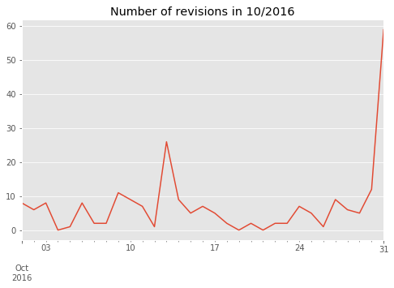

```python
revsOct16 = ts_in_oct
revsOct16Day = revsOct16.resample('D').count()
revsOct16Day.plot(figsize=(8,5), title="Number of revisions in 10/2016")
```

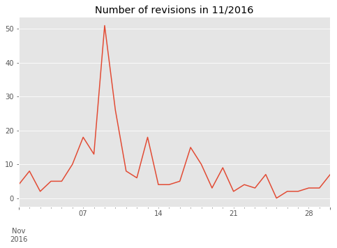

```python
revsNov16 = ts_in_nov
revsNov16Day = revsNov16.resample('D').count()
revsNov16Day.plot(figsize=(8,5), title="Number of revisions in 11/2016")
```

## 6. Defining our controversiality metric

Now we will define a metric to assess how controversial a page is on any date.

```python
def get_controversiality_index(revisions, get_time, get_format_time):
    """
    Return a dictionary mapping each day in our revisions data to how controversial that particular day is.
    """
    contr_index = {}

    for r in revisions:

        try:
            time = get_time(r)
            comment = r["comment"]

            # initialize to dictionary
            if time not in contr_index:
                str_time = get_format_time(r)
                contr_index[time] = {
                    "str_time": str_time,
                    "edits": 0,
                    "reversions": 0,
                    "contr_index": 0
                }

            contr_index[time]["edits"] += 1

            if "revert" in comment.lower():
                contr_index[time]["reversions"] += 1

        except KeyError:
            pass

    for time in contr_index:
        contr_index[time]["contr_index"] = float(contr_index[time]["reversions"]) / contr_index[time]["edits"]

    return contr_index
```

```python
get_date = lambda revision: createDateTime(revision).date

def get_month(r):
    date = createDateTime(r)
    return (date.year, date.month)

def get_format_month(r):
    date = createDateTime(r)
    return date.strftime("%b %Y")
```

```python
data = get_controversiality_index(revisions, get_month, get_format_month)

add_data = {
    "time": list(data.keys()),
    "Controversiality Index (% reversions / edits)": [r["contr_index"]*100 for r in data.values()],
    "Year": [r["str_time"] for r in data.values()]
}

contr_index_all = DataFrame(data=add_data).sort_values(by="time")
contr_index_all.head(10)
```

|  | Controversiality Index (% reversions / edits) | Year | time |
| --- | --- | --- | --- |
| 183 | 0.000000 | Aug 2001 | (2001, 8) |
| 182 | 0.000000 | Dec 2001 | (2001, 12) |
| 181 | 0.000000 | Feb 2002 | (2002, 2) |
| 180 | 0.000000 | May 2002 | (2002, 5) |
| 179 | 0.000000 | Jul 2002 | (2002, 7) |
| 178 | 0.000000 | Oct 2002 | (2002, 10) |
| 177 | 0.000000 | Jan 2003 | (2003, 1) |
| 176 | 0.000000 | Mar 2003 | (2003, 3) |
| 175 | 0.000000 | Apr 2003 | (2003, 4) |
| 174 | 28.571429 | May 2003 | (2003, 5) |

```python
# contr_index_all.plot(
#     x="Month",
#     y="Controversiality Index (% reversions / edits)",
#     figsize=(22,10),
#     title="Controversiality Index of HRC's page by month (Aug 2001 - Nov 2017)"
# )
```

**Controversial events that might have shifted how controversial HRC's wikipedia page is:**

- HRC takes responsibility for casualties of U.S. diplomats in Benghazi - [October 15, 2012](https://en.wikipedia.org/wiki/Hillary_Clinton#Benghazi_attack_and_subsequent_hearings)
- HRC declares intention to run for POTUS - [April 12, 2015](https://en.wikipedia.org/wiki/Hillary_Clinton#2016_presidential_campaign)
- Media start reporting on James Comey investigation into HRC's emails - [May 5,](https://www.washingtonpost.com/news/fact-checker/wp/2017/10/20/timeline-james-comeys-decision-making-on-the-clinton-probe/?utm_term=.a7fbec82ffab) [2016](https://en.wikipedia.org/wiki/Hillary_Clinton_email_controversy#May.E2.80.93July_2016_.E2.80.93_Public_statements)
- Election night - [November 8, 2016](https://en.wikipedia.org/wiki/Hillary_Clinton#2016_presidential_campaign)

```python
# Get weeks of each important event
def get_yr_wk(dt):
    return (dt.year, dt.date().isocalendar()[1]) # week number is 1st index of tuple

wk_benghazi = get_yr_wk(datetime(2012, 10, 15))
wk_potus = get_yr_wk(datetime(2015, 4, 12))
wk_comey = get_yr_wk(datetime(2016, 5, 5))
wk_election = get_yr_wk(datetime(2016, 11, 8))

print("benghazi:", wk_benghazi, "| potus:", wk_potus, "| comey:", wk_comey, "| election:", wk_election)
```

```
benghazi: (2012, 42) | potus: (2015, 15) | comey: (2016, 18) | election: (2016, 45)
```

```python
# get weeks nicely formatted

imp_wks = {
    wk_benghazi: "HRC takes responsibility for \ncasualties of U.S. diplomats in Benghazi",
    wk_potus: "HRC declares intention \nto run for POTUS",
    wk_comey: "Media start reporting on \nComey investigation",
    wk_election: "Election week 2016"
}

def get_yr_wk_fromdict(r):
    dt = createDateTime(r)
    return get_yr_wk(dt)

def get_format_yr_wk(r):
    yr_wk = get_yr_wk_fromdict(r)
    if yr_wk in imp_wks:
        return imp_wks[yr_wk]
    return "Week {}, {}".format(yr_wk[1], yr_wk[0])

date_range = []
for r in revisions:
    time = createDateTime(r)
    if time >= datetime(2012, 10, 1) and time <= datetime(2016, 12, 1):
        date_range.append(r)

wk_data = get_controversiality_index(date_range, get_yr_wk_fromdict, get_format_yr_wk)
wk_data
```

[output not shown]

[output cut: 761 more lines]

[output not shown]

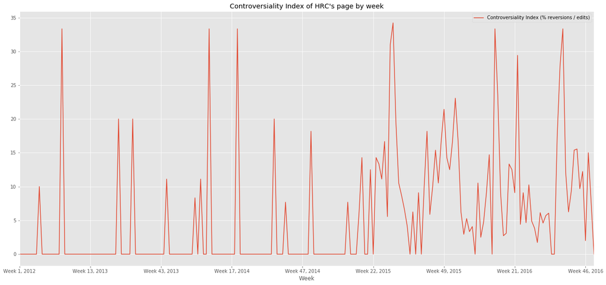

```python
def plot_wk_data(data_dict):

    wk_add_data = {
        "time": list(data_dict.keys()),
        "Controversiality Index (% reversions / edits)": [
            r["contr_index"]*100 for r in data_dict.values()
        ],
        "Week": [r["str_time"] for r in data_dict.values()]
    }

    contr_wk_all = DataFrame(data=wk_add_data).sort_values(by="time")

    contr_wk_all.plot(
        x="Week",
        y="Controversiality Index (% reversions / edits)",
        figsize=(22,10),
        title="Controversiality Index of HRC's page by week"
    )

plot_wk_data(wk_data)
```

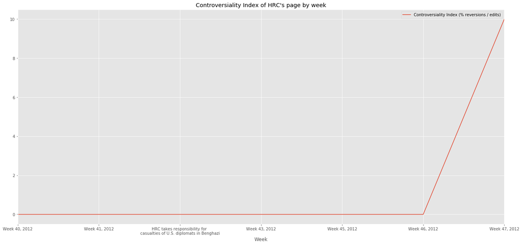

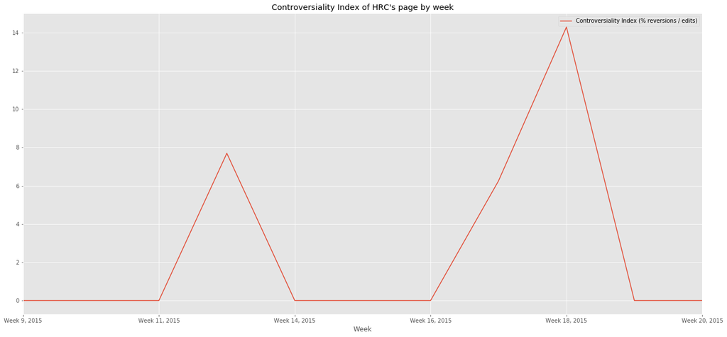

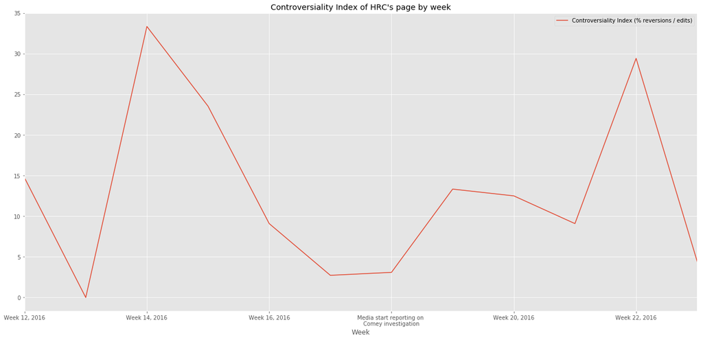

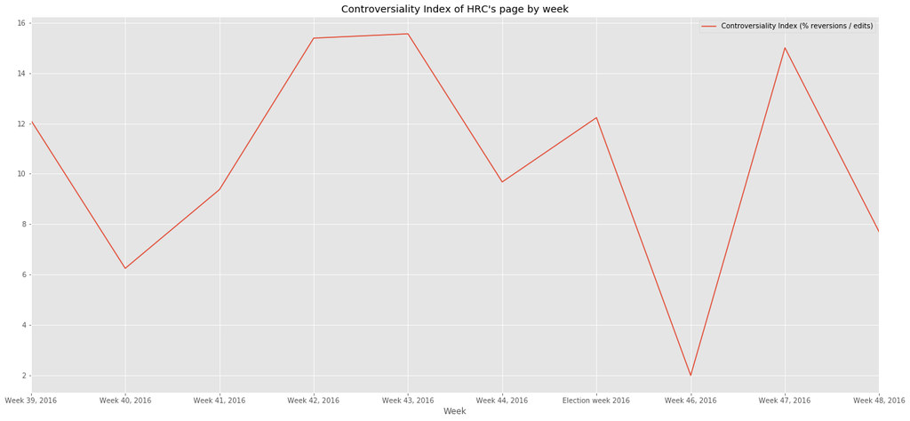

```python
imp_wk_data = {}
for year, month in imp_wks:

    if month - 6 <= 0:
        start = (year-1, 52 - abs(month - 6))
    else:
        start = (year, month - 6)

    if month + 5 > 52:
        end = (year+1, (month + 5) - 52)
    else:
        end = (year, month + 5)

    wk_sample = {
        key: val for key, val in wk_data.items() if
        key >= start and key <= end
    }

    imp_wk_data[(year, month)] = wk_sample

    plot_wk_data(wk_sample)
```

```python
import scipy.stats as sp
```

```python
"""
for wk, curr_wk_data in imp_wk_data.items():
    a = [curr_wk_data[edit]["contr_index"] for edit in curr_wk_data
         if edit < wk]
    b = [curr_wk_data[edit]["contr_index"] for edit in curr_wk_data
         if edit >= wk]

    print("\nbefore {}:".format(imp_wks[wk]), a, "after:", b)
    sp.mstats.ttest_rel(a, b)
"""
```

[output not shown]

## 7. Parse HTML page

```python
import requests
from bs4 import BeautifulSoup
```

```python
url = 'https://en.wikipedia.org/wiki/Hillary_Clinton'
req = requests.get(url)
if req.status_code == 200:
    html = req.content
    print(html[:100])
else:
    print("there was a problem with the request")
```

```
b'<!DOCTYPE html>\n<html class="client-nojs" lang="en" dir="ltr">\n<head>\n<meta charset="UTF-8"/>\n<title'
```

```python
tree = BeautifulSoup(html, "html5lib")
```

Extract all `<li>` elements from the tree

```python
link_list = tree.find_all('li')
len(link_list)
```

```
2217
```

```python
help(tree.find_all)
```

```
Help on method find_all in module bs4.element:

find_all(name=None, attrs={}, recursive=True, text=None, limit=None, **kwargs) method of bs4.BeautifulSoup instance
    Extracts a list of Tag objects that match the given
    criteria.  You can specify the name of the Tag and any
    attributes you want the Tag to have.

    The value of a key-value pair in the 'attrs' map can be a
    string, a list of strings, a regular expression object, or a
    callable that takes a string and returns whether or not the
    string matches for some custom definition of 'matches'. The
    same is true of the tag name.
```

```python
link_list[1]
```

```
<li><a href="/wiki/Electoral_history_of_Hillary_Clinton" title="Electoral history of Hillary Clinton">Electoral history</a></li>
```

```python
rev_hist= tree.find('a', text='View history')
rev_hist
```

```
<a accesskey="h" href="/w/index.php?title=Hillary_Clinton&amp;action=history" title="Past revisions of this page [h]">View history</a>
```